# F9_07_COMP_KONTR_ADDR_ZIP

Independent contractor zip · Identifier report

## Overview

**Description**

Highest compensated independent contractor (top 5 above 100K) foreign address zip code

**Table**

`F9-P07-T02-CONTRACTORS` (many)

**Location code**

`F990-PC-PART-07-SECTION-B-LINE-01-COL-A`, `F990-EZ-PART-06-LINE-51-COL-A`

**Family**

`F990-PC-PART-07-SECTION-B-LINE-01-COL-A` · siblings: F9_07_COMP_KONTR_ADDR_CITY, F9_07_COMP_KONTR_ADDR_CNTR, F9_07_COMP_KONTR_ADDR_L1, F9_07_COMP_KONTR_ADDR_L2, F9_07_COMP_KONTR_ADDR_STATE, F9_07_COMP_KONTR_NAME_ORG_L1

**Data type**

text (xsd: TextType, ZIPCodeType, , CountryType)

**Scope**

PZ

**Status**

unreviewed

14

xpaths mapped (11 observed)

498,615

filings with a value

2009–2024

tax years observed

9

open flags (1 errors)

## Flags

| Severity | Flag | Xpath | Detail |
| --- | --- | --- | --- |
| ⚠ error | `COLLISION` | IRS990/ContractorCompensationGrp/ContractorAddress/ForeignAddress/ForeignPostalCd | 5993 filings contain 2+ of its xpaths; most common set: /Return/ReturnData/IRS990/ContractorCompensationGrp/ContractorAddress/ForeignAddress/ForeignPostalCd ; /Return/ReturnData/IRS990/ContractorCompe… |
| ⓘ info | `MANY_NOT_REPEATING` | IRS990EZ/CompensationOfHghstPdCntrctGrp/USAddress/ZIPCd | many-to-one table, but 84% of values sit in no repeating element |
| ⓘ info | `MANY_NOT_REPEATING` | IRS990EZ/CompOfHghstPaidCntrctProfSer/AddressUS/ZIPCode | many-to-one table, but 86% of values sit in no repeating element |
| ⓘ info | `MANY_NOT_REPEATING` | IRS990EZ/CompensationOfHghstPdCntrctGrp/USAddress/ZIPCode | many-to-one table, but 88% of values sit in no repeating element |
| ⓘ info | `MANY_NOT_REPEATING` | IRS990EZ/CompensationOfHghstPdCntrctGrp/ForeignAddress/ForeignPostalCd | many-to-one table, but 87% of values sit in no repeating element |
| ⓘ info | `MANY_NOT_REPEATING` | IRS990EZ/CompOfHghstPaidCntrctProfSer/AddressForeign/PostalCode | many-to-one table, but 100% of values sit in no repeating element |
| ⓘ info | `UNOBSERVED` | IRS990/Form990PartVIISectionB/ContractorCompensation/AddressOfContractor/AddressForeign/PostalCode | never observed in TY2009-2024 filings |
| ⓘ info | `UNOBSERVED` | IRS990/Form990PartVIISectionB/ContractorCompensation/AddressOfContractor/AddressUS/ZIPCode | never observed in TY2009-2024 filings |
| ⓘ info | `UNOBSERVED` | IRS990EZ/CompensationOfHghstPdCntrctGrp/ForeignAddress/PostalCode | never observed in TY2009-2024 filings |

## Xpaths

All mapped xpaths (under /Return/ReturnData or /Return/ReturnHeader), oldest first. Charts label each series by its xpath.

| Xpath | Form | Chart label | First year | Last year | Versions | Filings | Repeats in |
| --- | --- | --- | --- | --- | --- | --- | --- |
| IRS990/ContractorCompensation/AddressOfContractor/AddressUS/ZIPCode | 990 | …tractorCompensation/AddressOfContractor/AddressUS/ZIPCode | 2009 | 2012 | 18 | 77,556 | 65.2% |
| IRS990/ContractorCompensation/AddressOfContractor/AddressForeign/PostalCode | 990 | …ompensation/AddressOfContractor/AddressForeign/PostalCode | 2009 | 2012 | 16 | 981 | 26.4% |
| IRS990EZ/CompOfHghstPaidCntrctProfSer/AddressUS/ZIPCode | 990-EZ | same | 2009 | 2012 | 14 | 361 | 14.4% |
| IRS990EZ/CompOfHghstPaidCntrctProfSer/AddressForeign/PostalCode | 990-EZ | …EZ/CompOfHghstPaidCntrctProfSer/AddressForeign/PostalCode | 2011 | 2011 | 1 | 2 | 0.0% |
| IRS990/ContractorCompensationGrp/ContractorAddress/USAddress/ZIPCode | 990 | …ractorCompensationGrp/ContractorAddress/USAddress/ZIPCode | 2013 | 2013 | 3 | 26,338 | 62.8% |
| IRS990/ContractorCompensationGrp/ContractorAddress/ForeignAddress/PostalCode | 990 | …mpensationGrp/ContractorAddress/ForeignAddress/PostalCode | 2013 | 2013 | 3 | 376 | 26.6% |
| IRS990EZ/CompensationOfHghstPdCntrctGrp/USAddress/ZIPCode | 990-EZ | same | 2013 | 2013 | 3 | 113 | 12.4% |
| IRS990/ContractorCompensationGrp/ContractorAddress/ForeignAddress/ForeignPostalCd | 990 | Other | 2014 | 2024 | 33 | 7,163 | 32.2% |
| IRS990/ContractorCompensationGrp/ContractorAddress/USAddress/ZIPCd | 990 | Other | 2014 | 2024 | 34 | 383,412 | 62.9% |
| IRS990/Form990PartVIISectionB/ContractorCompensation/AddressOfContractor/AddressForeign/PostalCode | 990 | Other |  |  |  | 0 |  |
| IRS990/Form990PartVIISectionB/ContractorCompensation/AddressOfContractor/AddressUS/ZIPCode | 990 | Other |  |  |  | 0 |  |
| IRS990EZ/CompensationOfHghstPdCntrctGrp/ForeignAddress/ForeignPostalCd | 990-EZ | Other | 2015 | 2024 | 17 | 47 | 8.5% |
| IRS990EZ/CompensationOfHghstPdCntrctGrp/ForeignAddress/PostalCode | 990-EZ | Other |  |  |  | 0 |  |
| IRS990EZ/CompensationOfHghstPdCntrctGrp/USAddress/ZIPCd | 990-EZ | Other | 2014 | 2024 | 34 | 2,266 | 16.3% |

## Coverage

[figure not shown]

**Table view**

Table view: filings by tax year and series

| Tax year | …tractorCompensation/AddressOfContractor/AddressUS/ZIPCode | …ompensation/AddressOfContractor/AddressForeign/PostalCode | IRS990EZ/CompOfHghstPaidCntrctProfSer/AddressUS/ZIPCode | …EZ/CompOfHghstPaidCntrctProfSer/AddressForeign/PostalCode | …ractorCompensationGrp/ContractorAddress/USAddress/ZIPCode | …mpensationGrp/ContractorAddress/ForeignAddress/PostalCode | IRS990EZ/CompensationOfHghstPdCntrctGrp/USAddress/ZIPCode | Other |
| --- | --- | --- | --- | --- | --- | --- | --- | --- |
| 2009 | 9,378 | 125 | 55 | 0 | 0 | 0 | 0 | 0 |
| 2010 | 20,146 | 266 | 84 | 0 | 0 | 0 | 0 | 0 |
| 2011 | 23,209 | 284 | 104 | 2 | 0 | 0 | 0 | 0 |
| 2012 | 24,823 | 306 | 118 | 0 | 0 | 0 | 0 | 0 |
| 2013 | 0 | 0 | 0 | 0 | 26,338 | 376 | 113 | 0 |
| 2014 | 0 | 0 | 0 | 0 | 0 | 0 | 0 | 28,768 |
| 2015 | 0 | 0 | 0 | 0 | 0 | 0 | 0 | 30,497 |
| 2016 | 0 | 0 | 0 | 0 | 0 | 0 | 0 | 31,776 |
| 2017 | 0 | 0 | 0 | 0 | 0 | 0 | 0 | 34,596 |
| 2018 | 0 | 0 | 0 | 0 | 0 | 0 | 0 | 35,057 |
| 2019 | 0 | 0 | 0 | 0 | 0 | 0 | 0 | 36,311 |
| 2020 | 0 | 0 | 0 | 0 | 0 | 0 | 0 | 38,016 |
| 2021 | 0 | 0 | 0 | 0 | 0 | 0 | 0 | 39,930 |
| 2022 | 0 | 0 | 0 | 0 | 0 | 0 | 0 | 42,767 |
| 2023 | 0 | 0 | 0 | 0 | 0 | 0 | 0 | 44,673 |
| 2024 | 0 | 0 | 0 | 0 | 0 | 0 | 0 | 30,497 |

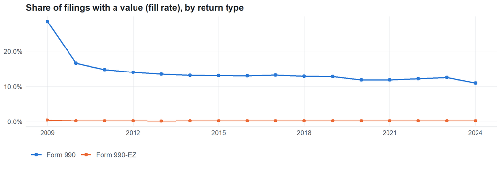

**Table view**

Table view: fill rate

[output not shown]

## Repeating groups

Table cardinality in the concordance: **many**. 10 of 11 observed xpaths repeat within a filing.

Repeating element each xpath was observed in (from the raw indexed xpath)

| Xpath | Repeating element | Filings (summed over years) |
| --- | --- | --- |
| IRS990/ContractorCompensation/AddressOfContractor/AddressForeign/PostalCode | (none) | 141 |
| IRS990/ContractorCompensation/AddressOfContractor/AddressForeign/PostalCode | IRS990/ContractorCompensation | 840 |
| IRS990/ContractorCompensation/AddressOfContractor/AddressUS/ZIPCode | (none) | 26671 |
| IRS990/ContractorCompensation/AddressOfContractor/AddressUS/ZIPCode | IRS990/ContractorCompensation | 50885 |
| IRS990EZ/CompOfHghstPaidCntrctProfSer/AddressUS/ZIPCode | (none) | 309 |
| IRS990EZ/CompOfHghstPaidCntrctProfSer/AddressUS/ZIPCode | IRS990EZ/CompOfHghstPaidCntrctProfSer | 52 |
| IRS990EZ/CompOfHghstPaidCntrctProfSer/AddressForeign/PostalCode | (none) | 2 |
| IRS990/ContractorCompensationGrp/ContractorAddress/ForeignAddress/PostalCode | (none) | 52 |
| IRS990/ContractorCompensationGrp/ContractorAddress/ForeignAddress/PostalCode | IRS990/ContractorCompensationGrp | 324 |
| IRS990/ContractorCompensationGrp/ContractorAddress/USAddress/ZIPCode | (none) | 9683 |
| IRS990/ContractorCompensationGrp/ContractorAddress/USAddress/ZIPCode | IRS990/ContractorCompensationGrp | 16655 |
| IRS990EZ/CompensationOfHghstPdCntrctGrp/USAddress/ZIPCode | (none) | 99 |
| IRS990EZ/CompensationOfHghstPdCntrctGrp/USAddress/ZIPCode | IRS990EZ/CompensationOfHghstPdCntrctGrp | 14 |
| IRS990/ContractorCompensationGrp/ContractorAddress/ForeignAddress/ForeignPostalCd | (none) | 1027 |
| IRS990/ContractorCompensationGrp/ContractorAddress/ForeignAddress/ForeignPostalCd | IRS990/ContractorCompensationGrp | 6136 |
| IRS990/ContractorCompensationGrp/ContractorAddress/USAddress/ZIPCd | (none) | 140318 |
| IRS990/ContractorCompensationGrp/ContractorAddress/USAddress/ZIPCd | IRS990/ContractorCompensationGrp | 243094 |
| IRS990EZ/CompensationOfHghstPdCntrctGrp/USAddress/ZIPCd | (none) | 1894 |
| IRS990EZ/CompensationOfHghstPdCntrctGrp/USAddress/ZIPCd | IRS990EZ/CompensationOfHghstPdCntrctGrp | 372 |
| IRS990EZ/CompensationOfHghstPdCntrctGrp/ForeignAddress/ForeignPostalCd | (none) | 41 |
| IRS990EZ/CompensationOfHghstPdCntrctGrp/ForeignAddress/ForeignPostalCd | IRS990EZ/CompensationOfHghstPdCntrctGrp | 6 |

## Values

| Result | Check | Detail |
| --- | --- | --- |
| ✓ pass | Values have the ZIP format | 99.3% of values match ^(99999\|999999999\|99999-9999)$ |
| ✓ pass | Stored as text | data type is text |
| ▲ warn | No placeholder values | 45 filings use a placeholder such as 000000000 |
| ⓘ info | Leading zeros present | at least 1% of values start with 0 in some year, so numeric storage would change them |

[figure not shown]

Value shapes (9 = digit, A = letter)

| Series | Shape | Expected | Filings |
| --- | --- | --- | --- |
| …tractorCompensation/AddressOfContractor/AddressUS/ZIPCode | 99999 | yes | 75,276 |
| …tractorCompensation/AddressOfContractor/AddressUS/ZIPCode | 999999999 | yes | 12,139 |
| …ompensation/AddressOfContractor/AddressForeign/PostalCode | 99999 | yes | 267 |
| …ompensation/AddressOfContractor/AddressForeign/PostalCode | A9A 9A9 | no | 163 |
| …ompensation/AddressOfContractor/AddressForeign/PostalCode | 9999 | no | 109 |
| …ompensation/AddressOfContractor/AddressForeign/PostalCode | A9A9A9 | no | 83 |
| …ompensation/AddressOfContractor/AddressForeign/PostalCode | 999999 | no | 63 |
| …ompensation/AddressOfContractor/AddressForeign/PostalCode | AA9 9AA | no | 6 |
| IRS990EZ/CompOfHghstPaidCntrctProfSer/AddressUS/ZIPCode | 99999 | yes | 340 |
| IRS990EZ/CompOfHghstPaidCntrctProfSer/AddressUS/ZIPCode | 999999999 | yes | 24 |
| …EZ/CompOfHghstPaidCntrctProfSer/AddressForeign/PostalCode | 99-999 | no | 1 |
| …EZ/CompOfHghstPaidCntrctProfSer/AddressForeign/PostalCode | 99999 | yes | 1 |
| …ractorCompensationGrp/ContractorAddress/USAddress/ZIPCode | 99999 | yes | 25,606 |
| …ractorCompensationGrp/ContractorAddress/USAddress/ZIPCode | 999999999 | yes | 3,721 |
| …mpensationGrp/ContractorAddress/ForeignAddress/PostalCode | 99999 | yes | 97 |
| …mpensationGrp/ContractorAddress/ForeignAddress/PostalCode | A9A 9A9 | no | 72 |
| …mpensationGrp/ContractorAddress/ForeignAddress/PostalCode | 9999 | no | 43 |
| …mpensationGrp/ContractorAddress/ForeignAddress/PostalCode | AA9 9AA | no | 32 |
| …mpensationGrp/ContractorAddress/ForeignAddress/PostalCode | 999999 | no | 26 |
| IRS990EZ/CompensationOfHghstPdCntrctGrp/USAddress/ZIPCode | 99999 | yes | 113 |
| IRS990EZ/CompensationOfHghstPdCntrctGrp/USAddress/ZIPCode | 999999999 | yes | 2 |
| Other | 99999 | yes | 379,489 |
| Other | 999999999 | yes | 47,534 |
| Other | A9A 9A9 | no | 1,271 |
| Other | 9999 | no | 878 |
| Other | 999999 | no | 597 |
| Other | AA9 9AA | no | 592 |
| Other | AA99 9AA | no | 66 |
| Other | 9999999 | no | 4 |
| Other | AAAA | no | 2 |
| Other | 999 999 | no | 1 |
| Other | A9A 9AA | no | 1 |
| Other | A9A-9A9 | no | 1 |
| Other | 9999 AAAAAA | no | 1 |

## Examples

| Tax year | Return | Xpath | Organization | Value | Source |
| --- | --- | --- | --- | --- | --- |
| 2024 | 990 | IRS990/ContractorCompensationGrp/ContractorAddress/ForeignAddress/ForeignPostalCd | NETWORK FOR GOOD | 00-105 | [XML](https://gt990datalake-rawdata.s3.amazonaws.com/EfileData/XmlFiles/202513039349301631_public.xml) |
| 2024 | 990 | IRS990/ContractorCompensationGrp/ContractorAddress/USAddress/ZIPCd | YMCA OF THE FOOTHILLS | 90293 | [XML](https://gt990datalake-rawdata.s3.amazonaws.com/EfileData/XmlFiles/202532059349301333_public.xml) |
| 2024 | 990EZ | IRS990EZ/CompensationOfHghstPdCntrctGrp/ForeignAddress/ForeignPostalCd | SHADE FOR CHILDREN | 53800 | [XML](https://gt990datalake-rawdata.s3.amazonaws.com/EfileData/XmlFiles/202520989349200702_public.xml) |
| 2024 | 990EZ | IRS990EZ/CompensationOfHghstPdCntrctGrp/USAddress/ZIPCd | BLACK FILMMAKER FOUNDATION INC | 10013 | [XML](https://gt990datalake-rawdata.s3.amazonaws.com/EfileData/XmlFiles/202511609349200126_public.xml) |
| 2023 | 990 | IRS990/ContractorCompensationGrp/ContractorAddress/ForeignAddress/ForeignPostalCd | OpenMRS1 Limited | 049712 | [XML](https://gt990datalake-rawdata.s3.amazonaws.com/EfileData/XmlFiles/202521149349300312_public.xml) |
| 2023 | 990 | IRS990/ContractorCompensationGrp/ContractorAddress/USAddress/ZIPCd | ZEPF CENTER | 43551 | [XML](https://gt990datalake-rawdata.s3.amazonaws.com/EfileData/XmlFiles/202423399349300887_public.xml) |
| 2023 | 990EZ | IRS990EZ/CompensationOfHghstPdCntrctGrp/ForeignAddress/ForeignPostalCd | CHINA KINGDOM RESOURCES | 100020 | [XML](https://gt990datalake-rawdata.s3.amazonaws.com/EfileData/XmlFiles/202413209349203206_public.xml) |
| 2023 | 990EZ | IRS990EZ/CompensationOfHghstPdCntrctGrp/USAddress/ZIPCd | MUSIC & VENDING ASSN OF SOUTH DAKOTA | 57501 | [XML](https://gt990datalake-rawdata.s3.amazonaws.com/EfileData/XmlFiles/202413239349200841_public.xml) |
| 2022 | 990 | IRS990/ContractorCompensationGrp/ContractorAddress/ForeignAddress/ForeignPostalCd | INSTITUTE FOR TRANSPORTATION AND | 02036-022 | [XML](https://gt990datalake-rawdata.s3.amazonaws.com/EfileData/XmlFiles/202303059349303355_public.xml) |
| 2022 | 990 | IRS990/ContractorCompensationGrp/ContractorAddress/USAddress/ZIPCd | NATIONAL CONSTITUTION CENTER | 19128 | [XML](https://gt990datalake-rawdata.s3.amazonaws.com/EfileData/XmlFiles/202420509349300732_public.xml) |
| 2022 | 990EZ | IRS990EZ/CompensationOfHghstPdCntrctGrp/ForeignAddress/ForeignPostalCd | GIFTEDNESS GUIDES | T8H-2K8 | [XML](https://gt990datalake-rawdata.s3.amazonaws.com/EfileData/XmlFiles/202322299349200217_public.xml) |
| 2022 | 990EZ | IRS990EZ/CompensationOfHghstPdCntrctGrp/USAddress/ZIPCd | HOUSE OF REDEMPTION | 44127 | [XML](https://gt990datalake-rawdata.s3.amazonaws.com/EfileData/XmlFiles/202321049349200612_public.xml) |

## Reviewer checklist

- The definition matches the form line and instructions for every xpath’s schema years.
- Every xpath pooled here measures the same thing on the 990 and 990-EZ (close enough for analysis).
- The coverage chart has no unexplained gaps or jumps between tax years.
- Each open flag is fixed, or accepted with a note in validation_log.csv.
- The data type is text so leading zeros and letters survive.
- The identifier belongs to the entity the variable names (the filer, preparer, related organization…).
- Formats with and without punctuation (e.g. ZIP+4, dashes) are normalized consistently downstream.

Record the review as a row in `inst/extdata/src/validation_log.csv` (variable_name, reviewer, date, status, note). Evidence built 2026-09-23 17:09:04 MST from the ef2 DuckDB builds (tax years 2009–2024).